# Zadanie domowe 05 - Tomasz Klonecki

Tomasz Klonecki

19 November 2018

# Wstęp

W mojej pracy postanowiłem sprawdzić w jaki sposób można manipulować wykresami poprzez zmianę skali. Praca pokaże, że czytelnicy nie za bardzo zwracają uwagę na liczby - a raczej na kształty.

Ankieta do pracy: [link](https://goo.gl/forms/f4sHBZpcNuuOMX952)

# Przedstawienie wykresów

### Poprawny wykres

Poniższy wykres jest dobrze zaprojektowany, skala osi OY zaczyna się w zerze, kolory są dobrze dobrane i nie ma problemu z poprawnym odczytaniem danych.

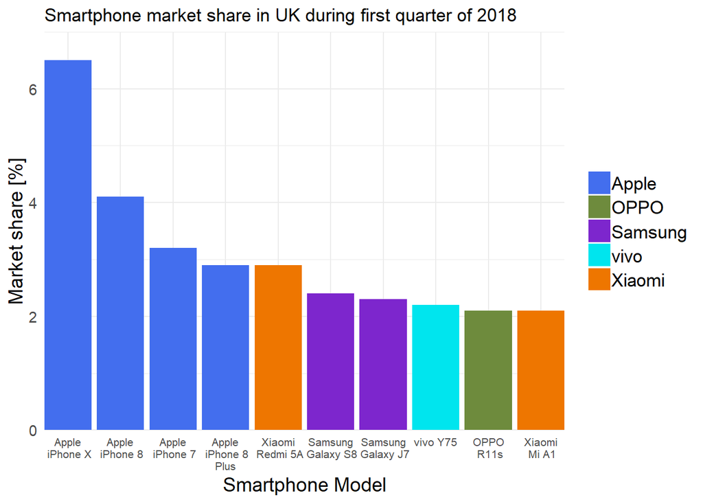

### Wykres poddany manipulacji

Podczas tworzenia tego wykresu, wczułem się w pracownika PR firmy Apple i chciałem przedstawić dane jak najbardziej na korzyść mojej firmy. Manipulacja polega na zmianie skali OY, w taki sposób żeby słupki zaczynały się w 2. Oprócz tego zmiana kolorów, tak żeby firma Apple rzucała się w oczy.

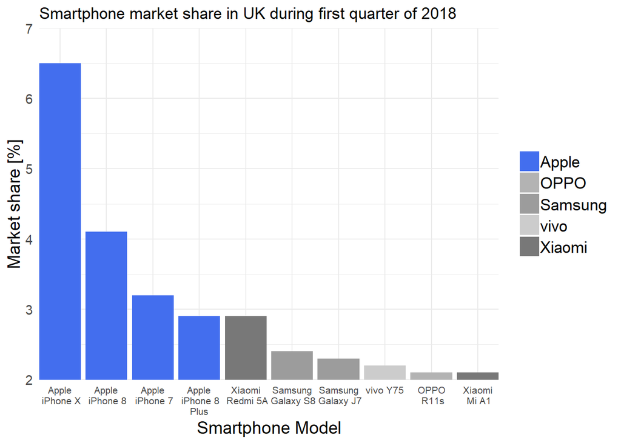

# Wyniki ankiety

Do obu wykresów zostało zadane takie samo pytanie, mające na celu sprawdzić czy czytelnik zobaczy, że ma do czynienia z tymi samymi danymi, tylko przedstawionymi w inny sposób. W idealnej sytuacji (kiedy wszyscy zauważyliby że dane są takie same i próbuję ich oszukać) stosunek odpowiedzi dla obu wykresów powinien pozostać taki sam. Jak można się spodziewać tak się nie stało. Poniżej prezentuje wykres, który przedstawia procentowy udział odpowiedzi na pytanie dotyczące obu wykresów (Prawidłowego i Zmanipulowanego). W ankiecie wzieły udział 33 osoby.

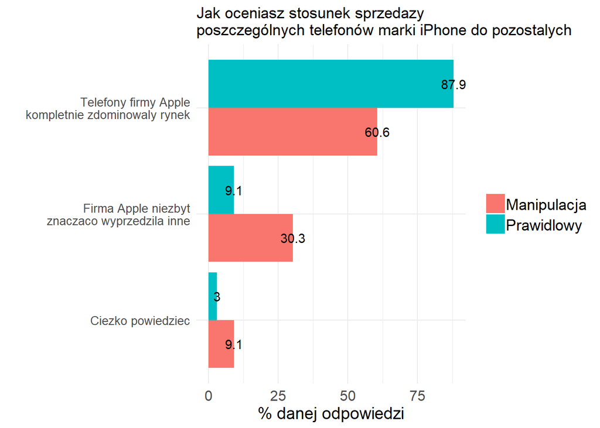

# Wnioski